# ML2 Team 1 Presentation

### PCR and PLS

Principal Components Regression (PCR) PCR uses the first few components as the predictors in a linear regression model that is fit using least squares. We want to find out if a small number of principal components can explain most of the variability in the data.

PCR can be performed using `pcr()` function from `pls` library

Objectives: Predict salary

Load the `pls` library and run `pcr` to Hitters data. We can set scale=TRUE to standardize each predictor.

```r
library(pls)
set.seed(2)
#?pcr
pcr.fit=pcr(Salary~.,data=HitData,scale=TRUE,validation="CV")
```

Check the resulting fit using `summary()`

```r
summary(pcr.fit)
Data:   X dimension: 263 19
    Y dimension: 263 1
Fit method: svdpc
Number of components considered: 19

VALIDATION: RMSEP
Cross-validated using 10 random segments.
       (Intercept)  1 comps  2 comps  3 comps  4 comps  5 comps  6 comps
CV             452    351.9    353.2    355.0    352.8    348.4    343.6
adjCV          452    351.6    352.7    354.4    352.1    347.6    342.7
       7 comps  8 comps  9 comps  10 comps  11 comps  12 comps  13 comps
CV       345.5    347.7    349.6     351.4     352.1     353.5     358.2
adjCV    344.7    346.7    348.5     350.1     350.7     352.0     356.5
       14 comps  15 comps  16 comps  17 comps  18 comps  19 comps
CV        349.7     349.4     339.9     341.6     339.2     339.6
adjCV     348.0     347.7     338.2     339.7     337.2     337.6

TRAINING: % variance explained
        1 comps  2 comps  3 comps  4 comps  5 comps  6 comps  7 comps  8 comps
X         38.31    60.16    70.84    79.03    84.29    88.63    92.26    94.96
Salary    40.63    41.58    42.17    43.22    44.90    46.48    46.69    46.75
        9 comps  10 comps  11 comps  12 comps  13 comps  14 comps  15 comps
X         96.28     97.26     97.98     98.65     99.15     99.47     99.75
Salary    46.86     47.76     47.82     47.85     48.10     50.40     50.55
        16 comps  17 comps  18 comps  19 comps
X          99.89     99.97     99.99    100.00
Salary     53.01     53.85     54.61     54.61
```

See cross-validation

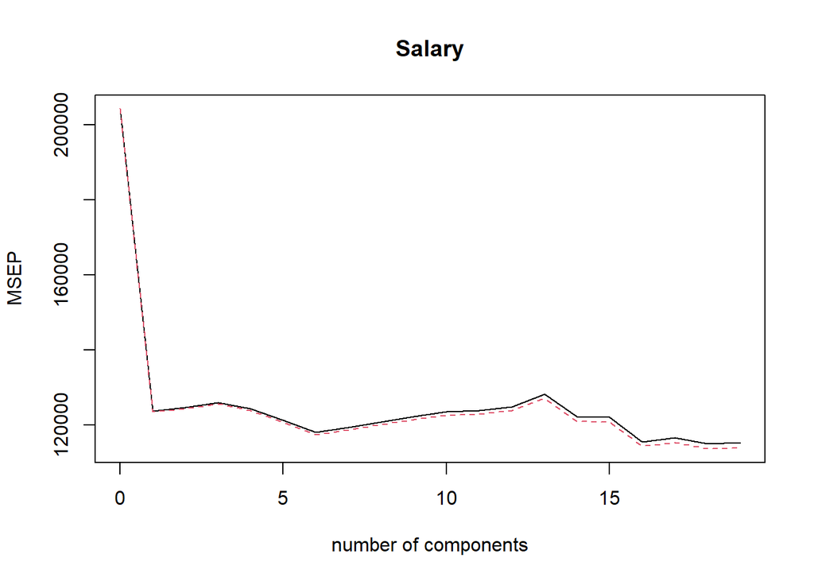

```r
validationplot(pcr.fit,val.type = "MSEP")
```

Run PCR on the training data and check the performace

```r
set.seed(1)
pcr.fit<-pcr(Salary~.,data=HitData,subset=train,scale=TRUE,validation="CV")
summary(pcr.fit)
Data:   X dimension: 131 19
    Y dimension: 131 1
Fit method: svdpc
Number of components considered: 19

VALIDATION: RMSEP
Cross-validated using 10 random segments.
       (Intercept)  1 comps  2 comps  3 comps  4 comps  5 comps  6 comps
CV           428.3    326.2    332.2    326.2    327.6    322.5    326.2
adjCV        428.3    325.7    331.5    325.1    326.7    321.3    324.9
       7 comps  8 comps  9 comps  10 comps  11 comps  12 comps  13 comps
CV       331.9    328.3    331.1     332.1     334.5     338.9     337.7
adjCV    330.3    326.6    328.6     329.9     332.2     336.4     335.1
       14 comps  15 comps  16 comps  17 comps  18 comps  19 comps
CV        338.7     341.7     340.1     344.2     353.3     345.0
adjCV     336.1     338.9     337.0     340.9     349.3     341.1

TRAINING: % variance explained
        1 comps  2 comps  3 comps  4 comps  5 comps  6 comps  7 comps  8 comps
X         39.32    61.57    71.96    80.83    85.95    89.99    93.25    95.34
Salary    43.87    43.93    47.36    47.37    49.52    49.55    49.63    50.98
        9 comps  10 comps  11 comps  12 comps  13 comps  14 comps  15 comps
X         96.55     97.61     98.28     98.85     99.22     99.53     99.79
Salary    53.00     53.00     53.02     53.05     53.80     53.85     54.03
        16 comps  17 comps  18 comps  19 comps
X          99.91     99.97     99.99    100.00
Salary     55.85     55.89     56.21     58.62
```

Lowest cross-validation error when 5 components used

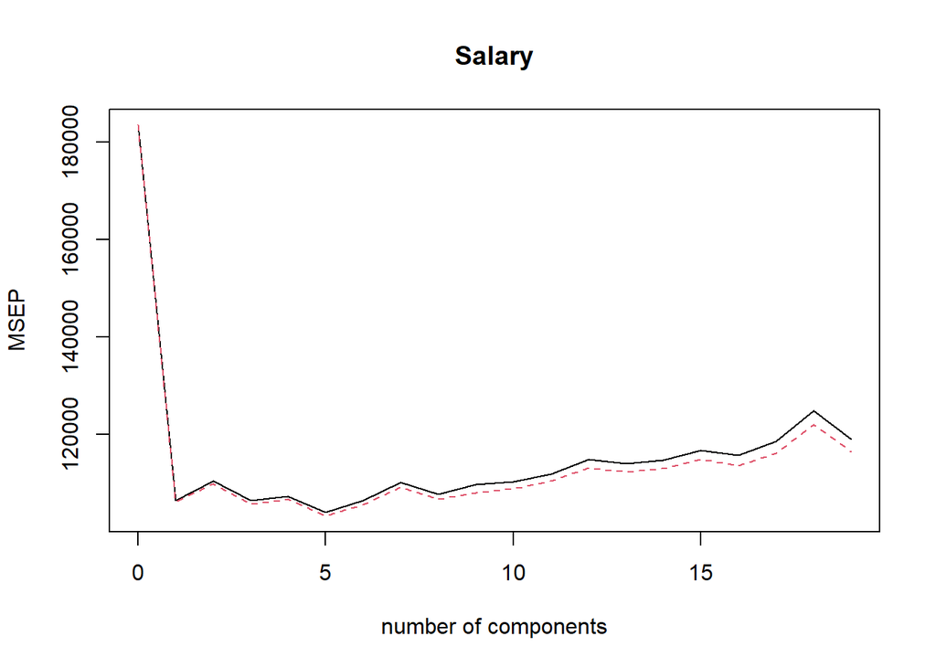

```r
validationplot(pcr.fit,val.type = "MSEP")
```

Test

```r
pcr.pred=predict(pcr.fit,x[test,],ncomp=5)
mean((pcr.pred-y.test)^2) #142811.8
[1] 142811.8
```

PCR on the full data set

```r
pcr.fit<-pcr(y~x,scale=TRUE,ncomp=5)
summary(pcr.fit)
Data:   X dimension: 263 19
    Y dimension: 263 1
Fit method: svdpc
Number of components considered: 5
TRAINING: % variance explained
   1 comps  2 comps  3 comps  4 comps  5 comps
X    38.31    60.16    70.84    79.03    84.29
y    40.63    41.58    42.17    43.22    44.90
```

Partial Least Squares (PLS)

PLS can be performed using `plsr()` function in the `pls` library.

```r
set.seed(1)
pls.fit<-plsr(Salary~.,data=Hitters,subset=train,scale=TRUE,validation="CV")
summary(pls.fit)
Data:   X dimension: 99 19
    Y dimension: 99 1
Fit method: kernelpls
Number of components considered: 19

VALIDATION: RMSEP
Cross-validated using 10 random segments.
       (Intercept)  1 comps  2 comps  3 comps  4 comps  5 comps  6 comps
CV           451.8    336.1    332.9    341.5    343.1    357.2    360.6
adjCV        451.8    335.3    331.6    338.9    340.3    353.0    355.9
       7 comps  8 comps  9 comps  10 comps  11 comps  12 comps  13 comps
CV       361.1    352.7    350.0     344.5     339.9     338.1     337.1
adjCV    355.8    347.4    345.1     339.5     335.1     333.3     332.4
       14 comps  15 comps  16 comps  17 comps  18 comps  19 comps
CV        332.9     334.0     337.6     345.4     343.8     344.8
adjCV     328.5     329.5     332.8     340.0     338.7     339.6

TRAINING: % variance explained
        1 comps  2 comps  3 comps  4 comps  5 comps  6 comps  7 comps  8 comps
X          38.7    55.22    66.58    73.95    78.96    85.29    89.42    90.85
Salary     49.7    55.07    57.96    59.51    61.88    63.39    64.68    66.39
        9 comps  10 comps  11 comps  12 comps  13 comps  14 comps  15 comps
X          93.6     94.92     97.01     97.90     98.34     98.74     99.26
Salary     67.0     68.03     68.40     68.76     68.98     69.14     69.18
        16 comps  17 comps  18 comps  19 comps
X          99.76     99.80     99.98    100.00
Salary     69.19     69.29     69.31     69.35
```

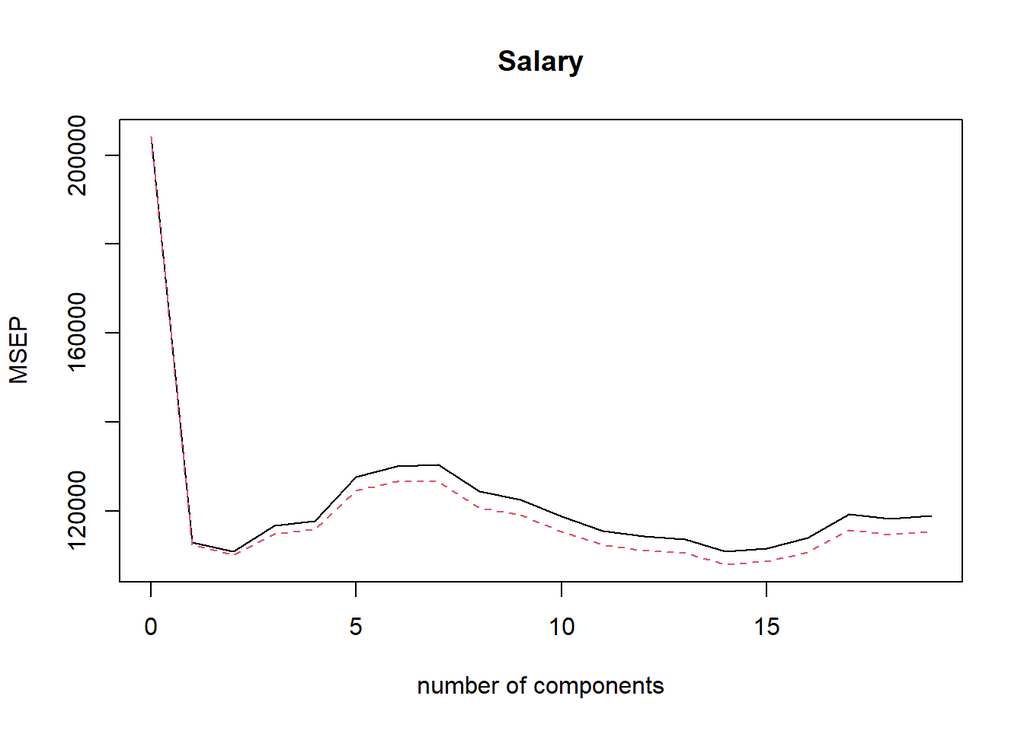

```r
validationplot(pls.fit,val.type="MSEP")
```

Check MSE

```r
pls.pred<-predict(pls.fit,x[test,],ncomp = 2)
mean((pls.pred-y.test)^2)# 125968.2
[1] 125968.2
```

PLS using the full data set

```r
pls.fit<-plsr(Salary~., data=HitData,scale=TRUE,ncomp=2)
summary(pls.fit)
Data:   X dimension: 263 19
    Y dimension: 263 1
Fit method: kernelpls
Number of components considered: 2
TRAINING: % variance explained
        1 comps  2 comps
X         38.08    51.03
Salary    43.05    46.40
```

### Application Exercise

**Objectives:** Identify what attributes/ features of American colleges are the most important in predicting the number of applicants a college receives. Use lasso, ridge, principle compenent, and partial least squares regression to find model that minimizes MSE and maximizes R^2.

**Data Source:** Real Data Set. 1995 issue of US News and World Report [777x18]

**Dimensions:** Private, Apps, Accept, Enroll, Top10perc, Top25perc, F.Undergrad, P.Undergrad, Outstate Room.Board, Books, Personal, PhD, Terminal, S.F. Ratio, perc.alumni, Expend, Grad.Rate

**Exploring the Data:**

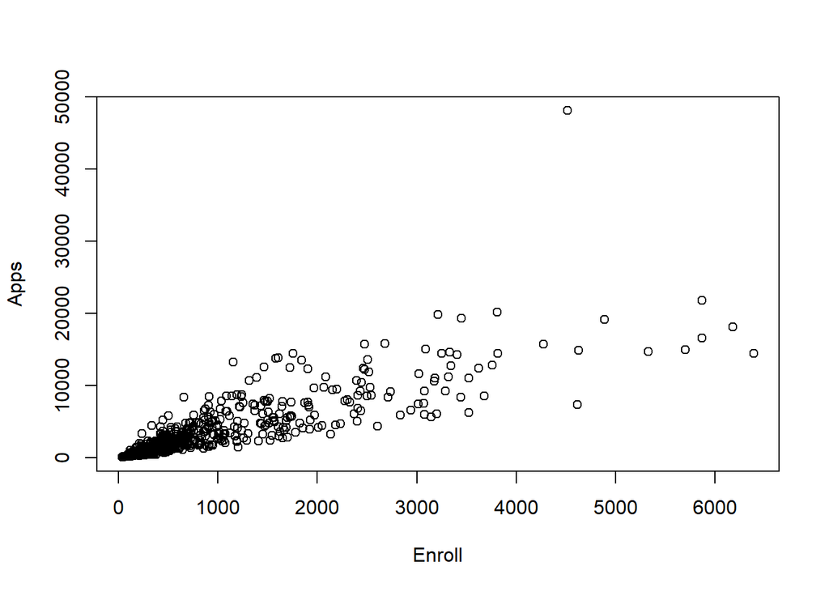

```r
library(ISLR)
library(caret)
library(glmnet)
set.seed(1)
College <- ISLR::College
sum(is.na(College)) #0 N/A Values
[1] 0
head(College)
                             Private Apps Accept Enroll Top10perc Top25perc
Abilene Christian University     Yes 1660   1232    721        23        52
Adelphi University               Yes 2186   1924    512        16        29
Adrian College                   Yes 1428   1097    336        22        50
Agnes Scott College              Yes  417    349    137        60        89
Alaska Pacific University        Yes  193    146     55        16        44
Albertson College                Yes  587    479    158        38        62
                             F.Undergrad P.Undergrad Outstate Room.Board Books
Abilene Christian University        2885         537     7440       3300   450
Adelphi University                  2683        1227    12280       6450   750
Adrian College                      1036          99    11250       3750   400
Agnes Scott College                  510          63    12960       5450   450
Alaska Pacific University            249         869     7560       4120   800
Albertson College                    678          41    13500       3335   500
                             Personal PhD Terminal S.F.Ratio perc.alumni Expend
Abilene Christian University     2200  70       78      18.1          12   7041
Adelphi University               1500  29       30      12.2          16  10527
Adrian College                   1165  53       66      12.9          30   8735
Agnes Scott College               875  92       97       7.7          37  19016
Alaska Pacific University        1500  76       72      11.9           2  10922
Albertson College                 675  67       73       9.4          11   9727
                             Grad.Rate
Abilene Christian University        60
Adelphi University                  56
Adrian College                      54
Agnes Scott College                 59
Alaska Pacific University           15
Albertson College                   55
#summary(HitData)
str(College)
'data.frame':   777 obs. of  18 variables:
 $ Private    : Factor w/ 2 levels "No","Yes": 2 2 2 2 2 2 2 2 2 2 ...
 $ Apps       : num  1660 2186 1428 417 193 ...
 $ Accept     : num  1232 1924 1097 349 146 ...
 $ Enroll     : num  721 512 336 137 55 158 103 489 227 172 ...
 $ Top10perc  : num  23 16 22 60 16 38 17 37 30 21 ...
 $ Top25perc  : num  52 29 50 89 44 62 45 68 63 44 ...
 $ F.Undergrad: num  2885 2683 1036 510 249 ...
 $ P.Undergrad: num  537 1227 99 63 869 ...
 $ Outstate   : num  7440 12280 11250 12960 7560 ...
 $ Room.Board : num  3300 6450 3750 5450 4120 ...
 $ Books      : num  450 750 400 450 800 500 500 450 300 660 ...
 $ Personal   : num  2200 1500 1165 875 1500 ...
 $ PhD        : num  70 29 53 92 76 67 90 89 79 40 ...
 $ Terminal   : num  78 30 66 97 72 73 93 100 84 41 ...
 $ S.F.Ratio  : num  18.1 12.2 12.9 7.7 11.9 9.4 11.5 13.7 11.3 11.5 ...
 $ perc.alumni: num  12 16 30 37 2 11 26 37 23 15 ...
 $ Expend     : num  7041 10527 8735 19016 10922 ...
 $ Grad.Rate  : num  60 56 54 59 15 55 63 73 80 52 ...
plot(Apps~Enroll, data = College)
```

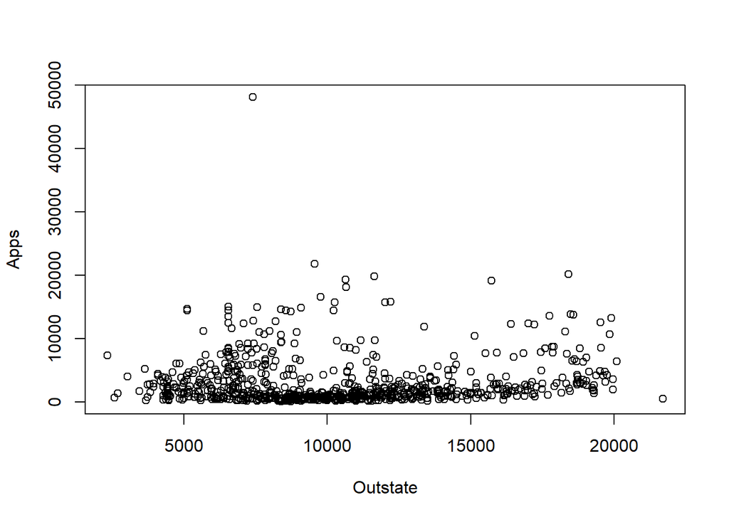

```r
plot(Apps~Outstate, data = College)
```

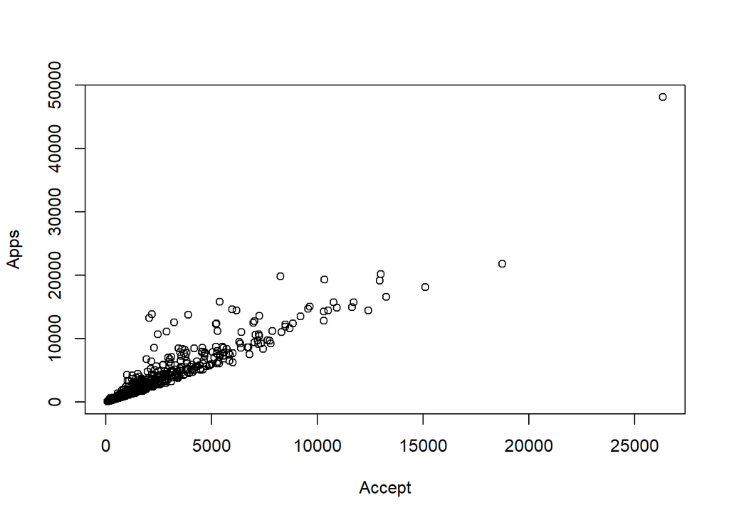

```r
plot(Apps~Accept, data = College)
```

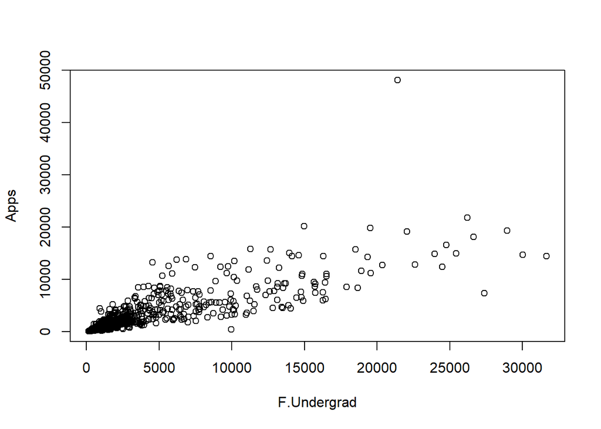

```r
plot(Apps~F.Undergrad, data=College)
```

### Ridge and Lasso (Applied Exercise)

1. Split the data set into a training set and a test set using caret’s `createDataPartition()` function.

```r
divideData <- createDataPartition(College$Apps, p=.8,list = F)
train<- College[divideData,]
test<- College[-divideData,]
```

2. Fit a linear model using least squares on the training set, and report the test error obtained.

```r
linear <- lm(Apps~., data=train)
summary(linear)

Call:
lm(formula = Apps ~ ., data = train)

Residuals:
    Min      1Q  Median      3Q     Max
-5516.6  -431.7   -16.2   308.3  6683.3

Coefficients:
              Estimate Std. Error t value Pr(>|t|)
(Intercept)   21.67077  418.84131   0.052 0.958753
PrivateYes  -546.38913  141.03322  -3.874 0.000119 ***
Accept         1.68078    0.04075  41.249  < 2e-16 ***
Enroll        -0.90737    0.19646  -4.619 4.72e-06 ***
Top10perc     45.04650    5.74155   7.846 1.95e-14 ***
Top25perc    -11.61898    4.60167  -2.525 0.011826 *
F.Undergrad    0.01538    0.03586   0.429 0.668143
P.Undergrad    0.06416    0.03277   1.958 0.050680 .
Outstate      -0.09148    0.01946  -4.700 3.22e-06 ***
Room.Board     0.12268    0.05020   2.444 0.014821 *
Books          0.12887    0.26867   0.480 0.631646
Personal      -0.03450    0.06463  -0.534 0.593682
PhD           -9.22049    5.23693  -1.761 0.078799 .
Terminal      -0.37291    5.49621  -0.068 0.945928
S.F.Ratio     -3.96231   13.40507  -0.296 0.767650
perc.alumni   -2.31709    4.22624  -0.548 0.583713
Expend         0.06136    0.01324   4.635 4.37e-06 ***
Grad.Rate      8.99717    3.03307   2.966 0.003132 **
---
Signif. codes:  0 '***' 0.001 '**' 0.01 '*' 0.05 '.' 0.1 ' ' 1

Residual standard error: 968.2 on 606 degrees of freedom
Multiple R-squared:  0.9395,    Adjusted R-squared:  0.9378
F-statistic: 553.8 on 17 and 606 DF,  p-value: < 2.2e-16
```

From the data, we are able to find the MSE for the linear model:

```
[1] 1794275
```

3. Fit a ridge regression model on the training set, with λ chosen by cross-validation. Report the test error obtained.

First, we want to create two matrices using our `train` and `test` data.

```r
train_matrix <- model.matrix(Apps~.,data=train)
test_matrix <- model.matrix(Apps~.,data=test)
```

**Model Creation and Lambda**

Next, we want to form a ridge model by using the `glmnet` library. The function `glmnet()` will “fit a generalized linear model via penalized maximum likelihood” using lambda; the `alpha=0` below indicates the ridge penalty, set as the value 0 (conversly, a 1 will be used for the lasso penalty). . We also want to generate a range of different lambda values that will adequately produce our ideal lambda. In order to do this, we can use cross-validation on our model to eventually find the lowest MSE value possible by the lambda we find. After using `cv.glmnet()`, we are able use `$lambda.min` from the `glmnet` library on the cross validation version of the model to determine the best lambda.

```r
grid=10^seq(10,-2,length=100)
ridge <- glmnet(train_matrix, train$Apps, alpha = 0, lambda = grid, thresh = 1e-12)
crossv <- cv.glmnet(train_matrix, train$Apps, alpha=0)
lambda_ridge <- crossv$lambda.min
lambda_ridge
[1] 369.8393
```

We find that the best lambda is 369.84. We are finally able to make a prediction using the `test` matrix (`newx=`), ridge model, and lambda of 369 (`s=`) to find the minimized MSE of the model:

```r
ridge_prediction <- predict(ridge, s=lambda_ridge, newx = test_matrix)
ridge_error <- mean((test$Apps-ridge_prediction)^2)
ridge_error
[1] 1574654
```

We can see that the MSE is much lower than the linear model, lower by 219,621! It would seem that the model accuracy for the ridge model is substantially better than the linear model. What about the lasso method?

4. Fit a lasso model on the training set, with λ chosen by crossvalidation. Report the test error obtained, along with the number of non-zero coefficient estimates.

**Model Creation and Lambda**

For the lasso method, we will be using the same matrices, `train_matrix` and `train_matrix`, for the creation of the model.

The lasso model uses a similar approach as the ridge model setup using the `glmnet` library. The function `glmnet()` will “fit a generalized linear model via penalized maximum likelihood” using lambda; the `alpha=1` is set for a lasso model. Similar to the last model, we want to use generated lambda values and use cross-validation to find an ideal lambda value for the model. After using `cv.glmnet()`, we are able use `$lambda.min` from the `glmnet` library on the cross validation version of the model to determine the best lambda.

```r
lasso <- glmnet(train_matrix, train$Apps, alpha = 1, lambda = grid, thresh = 1e-12)
crossv_2 <- cv.glmnet(train_matrix,train$Apps, alpha=1)
lambda_lasso <- crossv_2$lambda.min #check coeff for lamba (how many or 0)
lambda_lasso
[1] 2.609143
```

We receive a value of 2.61 as our lambda. Along with our new values for the lasso model, we can predict the MSE test value:

```r
lasso_prediction <- predict(lasso, s=lambda_lasso, newx = test_matrix)
lasso_error <- mean((test$Apps-lasso_prediction)^2)
lasso_error
```

```
## [1] 1795055
```

** Possible causes for the Model Performance **

Interestingly, the lasso model performs worse than the ridge model. Assuming our lambda value is the ideal lambda model, there may be other factors in the dataset that could affect the outcomes of each model.

One potential problem with ridge models compared to other models is that all predictors $p$ will be included in the model. This means if that there are useless predictor variables, there may be issues with overfitting the model. Lasso models seek to mitigate this problem by reducing the beta coefficients like ridge models. The key difference is that lasso models will bring certain coefficients to 0 with a high enough lambda. In other words, the lasso approach using variable selection to omit certain variables that may be irrelevant.

Looking at the coefficient values for Lasso approach:

```r
predict(lasso,s=lambda_lasso,type="coefficients")
19 x 1 sparse Matrix of class "dgCMatrix"
                        1
(Intercept) -6.926720e+01
(Intercept)  .
PrivateYes  -5.342709e+02
Accept       1.666772e+00
Enroll      -7.953406e-01
Top10perc    4.310697e+01
Top25perc   -1.018907e+01
F.Undergrad  3.467706e-05
P.Undergrad  6.236871e-02
Outstate    -8.843649e-02
Room.Board   1.203555e-01
Books        1.115031e-01
Personal    -2.701220e-02
PhD         -8.722779e+00
Terminal    -3.142445e-01
S.F.Ratio   -2.463454e+00
perc.alumni -2.374680e+00
Expend       6.107624e-02
Grad.Rate    8.602780e+00
```

### PLS/PCR (Applied Exercise)

**Dimension Reduction Methods**

5. Fit a PCR model on the training set, with M chosen by cross-validation. Report the test error obtained, along with the value of M selected by cross-validation.

Principal components are linear combinations of variables that have high varaince. Principal components shouldn’t be correlated with each other.

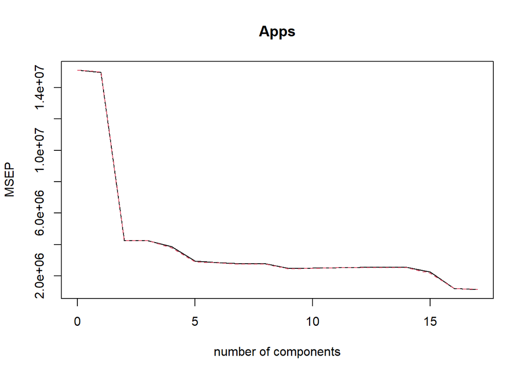

```r
library(pls)
set.seed(1)
pcr <- pcr(Apps~.,data=train,scale=TRUE, validation='CV')
validationplot(pcr,val.type="MSEP")
```

```r
pcr_prediction <- predict(pcr, test, ncomp = 17)
pcr_error <- mean((test$Apps-pcr_prediction)^2)
pcr_error
[1] 1794275
```

6. Fit a PLS model on the training set, with M chosen by cross-validation. Report the test error obtained, along with the value of M selected by cross-validation.

Partial least squares (PLS) is a supervised alternative to principle components regression(PCR).

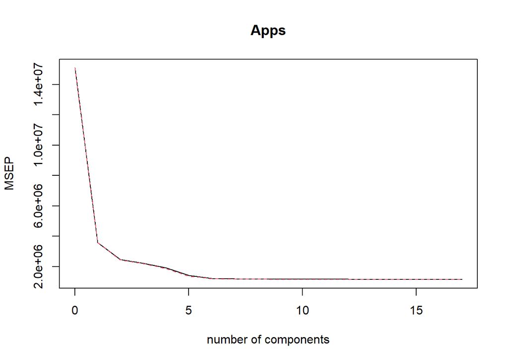

```r
pls <- plsr(Apps~.,data=train, scale=TRUE, validation='CV')
validationplot(pls,val.type = "MSEP")
```

```r
pls_prediction <- predict(pls, test, ncomp = 10)
pls_error <- mean((test$Apps-pls_prediction)^2)
pls_error
[1] 1807712
```

### Conclusion (Applied Exercise)

g. Comment on the results obtained. How accurately can we predict the number of college applications received? Is there much difference among the test errors resulting from these five approaches?

For this example, we will be using the predicition data from each model and comparing the $R^2$ values of each model. The model with the highest $R^2$ value represents a better model accuracy. Finally, we compare the MSE values and $R^2$ values of all models together in a table.

```r
test_avg <- mean(test$Apps)
#Least square
linear_r2 <- 1 - mean((prediction - test$Apps)^2) / mean((test_avg - test$Apps)^2)
#Ridge model
ridge_r2 <- 1 - mean((ridge_prediction - test$Apps)^2) / mean((test_avg - test$Apps)^2)
#Lasso model
lasso_r2 <- 1 - mean((lasso_prediction - test$Apps)^2) / mean((test_avg - test$Apps)^2)
#PCR model
pcr_r2 <- 1 - mean((pcr_prediction - test$Apps)^2) / mean((test_avg - test$Apps)^2)
#PLS model
pls_r2 <- 1 - mean((pls_prediction - test$Apps)^2) / mean((test_avg - test$Apps)^2)
```

```
          Error_Measures
Model_Type MSE               R-Squared
    Linear "1794275.3397438" "      0.8766846"
    Ridge  "1574654.0064098" "      0.8917785"
    Lasso  "1795055.3521211" "      0.8766310"
    PCR    "1794275.3397438" "      0.8766846"
    PLS    "1807711.6070399" "      0.8757611"
```

```
[1] "The lowest MSE value and highest R-Square value come from the Ridge Regression, with an MSE of 1574654.006410 and a R-Square of 0.891779."
```